# 빅데이터시각화_7장

Lee Jun Haeng

2021 11 23

### 7장 공간 자료와 지도 다루기

##### (a) contour() 함수 : 등고선 그림

contour() : 등고선 그림을 그리거나, 그려진 그림 위에 등고선 라인을 추가한다.

```r
## 등고선 그림 예제 : volcano 자료
data(volcano)
str(volcano)
```

```
##  num [1:87, 1:61] 100 101 102 103 104 105 105 106 107 108 ...
```

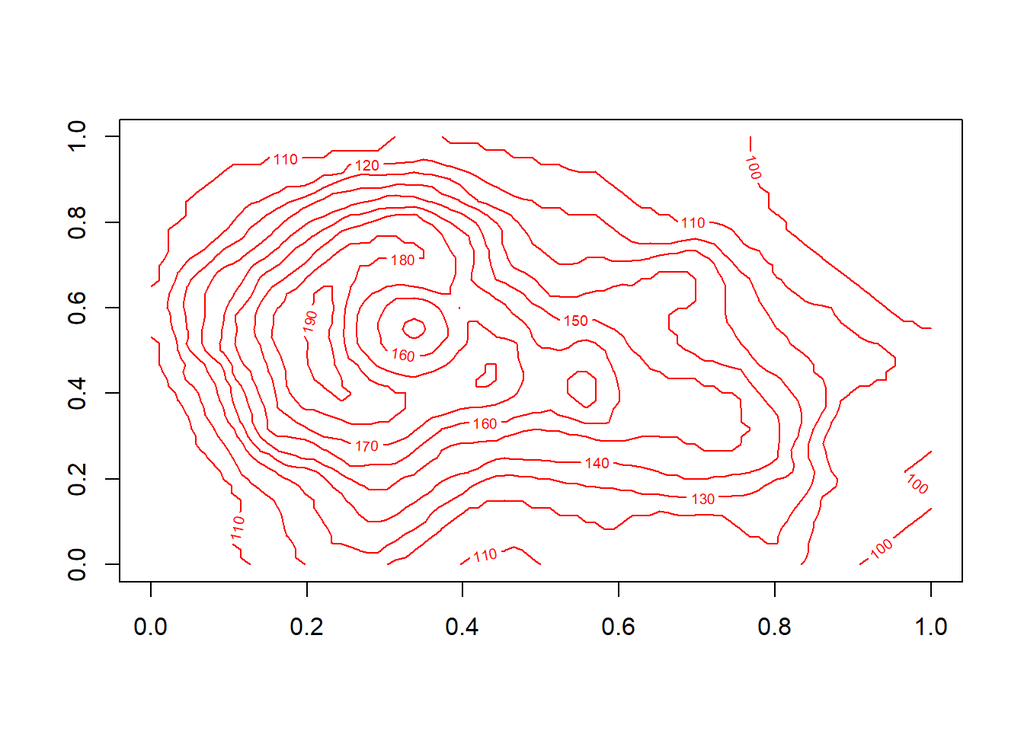

```r
contour(volcano, col="red")
```

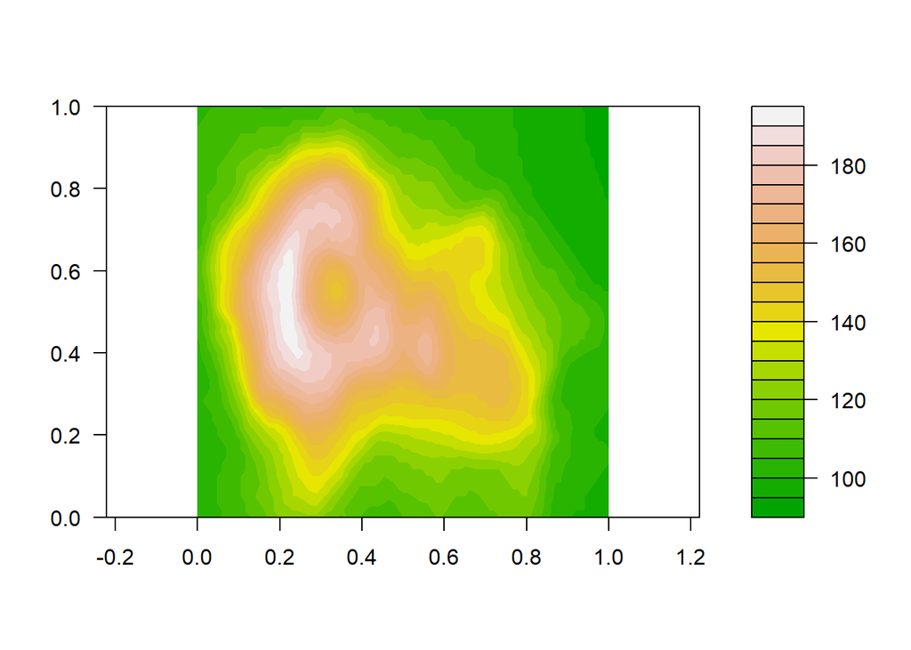

```r
filled.contour(volcano, color=terrain.colors, asp=1)
```

##### (b) persp() 함수 : 투시도(perspective plot)

persp() : x-y 평면상에 표면의 투시도를 그려준다.

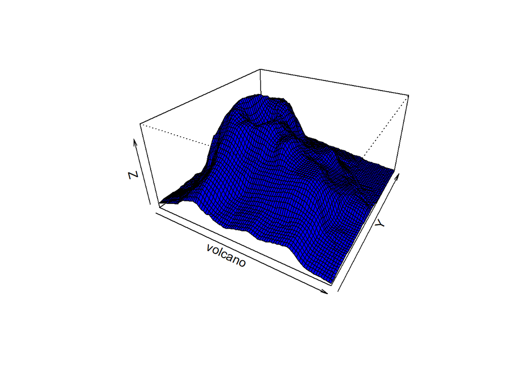

```r
persp(volcano, theta=30, phi=30, col="blue", expand=0.5)
```

##### (c) wireframe{lattice} 함수 : 철망형 그림

wireframe{lattice} : 3차원 산점도와 철망형 표면 그림을 그려준다.

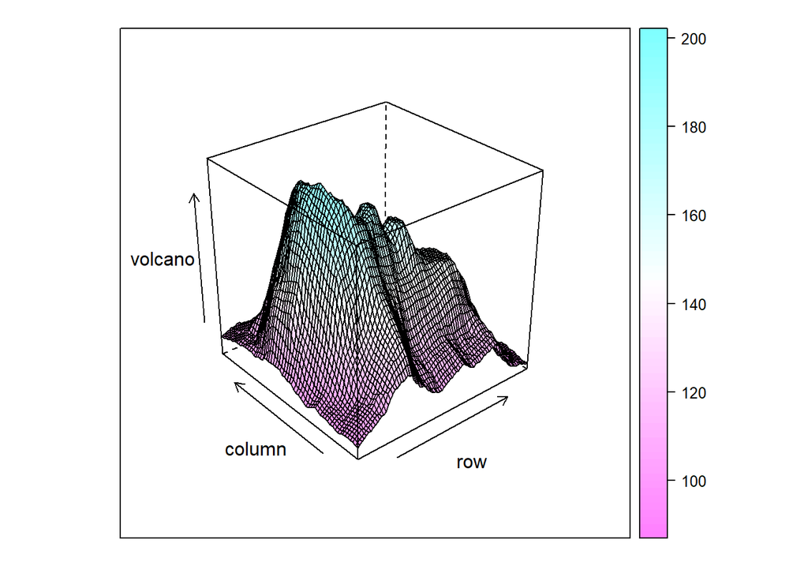

```r
library(lattice)
wireframe(volcano, drape=TRUE, aspect=c(1,1), colorkey=TRUE)
```

drape=TRUE는 높이에 따라 색으로 장식(drape)한다.  
aspect= 은 2개의 숫자로 이루어진 벡터로 지정되며, 각각 (y-크기/x-크기)를 나타낸다.  
colorkey=TRUE 는 color key를 옆(alongside)에 그려준다.

##### (d) levelplot{lattice} 함수 : 색상 수준 플롯

levelplot{lattice} : 색상 수준 플롯과 등고선 그림을 제공한다.

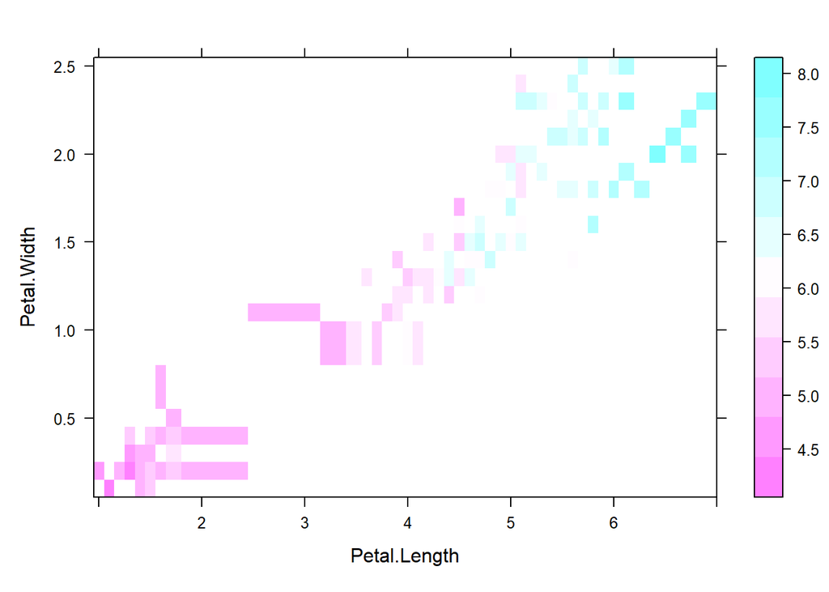

```r
levelplot(Sepal.Length ~ Petal.Length*Petal.Width, cut=10, data=iris)
```

##### (e) drawScene{misc3d} 함수

drawScene{misc3d} : 한 개 또는 여러 개 표면으로 구성된 장면을 그려준다.  
삼각 망사(triangle mesh)로 불리는 객체 자료가 요구된다.

```r
library(misc3d)
```

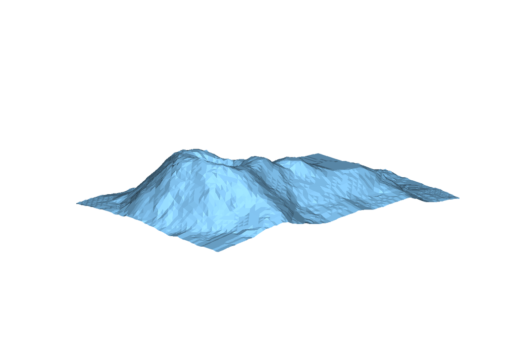

```r
volcano.1 <- local({
  z1 <- 7 * volcano
  x1 <- 20 * (1:nrow(z1))
  y1 <- 20 * (1:ncol(z1))
  surfaceTriangles(x1, y1, z1, color="skyblue1")
})
drawScene(volcano.1, scale=FALSE)
```

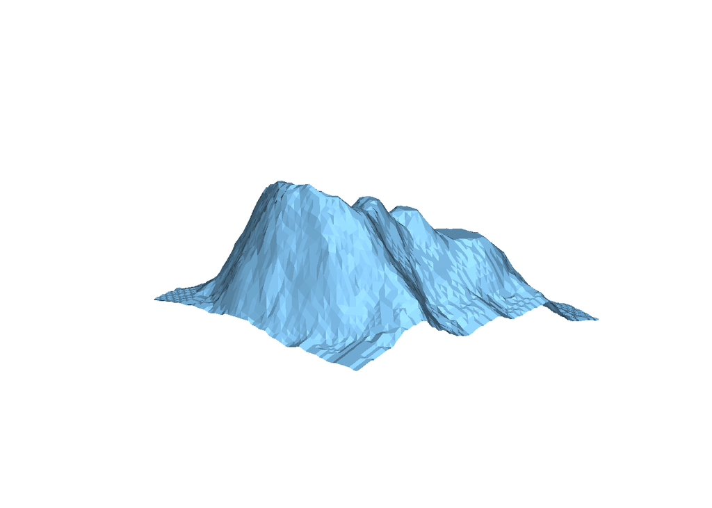

```r
drawScene(volcano.1, scale=TRUE)
```